# Overview of Bioinformatics Training at CRUK C.I.

Mark Dunning

4 July 2017

# How we started

In the early days of the group we were running:-

- Stats course using GraphPad Prism
- 3,4 times a year
- Microarray Analysis in Bioconductor
- once a year
- Experimental Design
- once a year
- In 2016 we contributed to 60 days of training

# What Changed

- Our new Institute Director (a statistican) banned GraphPad Prism :+1:
- Pressure from steering committee to provide more training
- Our Institute joined the University
- We got more involved with teaching at the University level
- A permanent training role
- me!
- funded externally to the Core

# What to teach

Decisions based on:-

- Demands from user (see next slides)
- Topics with existing materials
- Tools / techniques where best pratices are established
- RNA-seq
- Tools that encourage independance and data exploration
- e.g. browsers, web-based
- Promoting better communication between wet-lab and Bioinformatician
  - so they know what is possible
  - speed-up the process of completing a project

# Institute-wide survey - February 2016

> For each of the skills listed below, please rate from 1 to 5 how useful it would be to receive training in this area

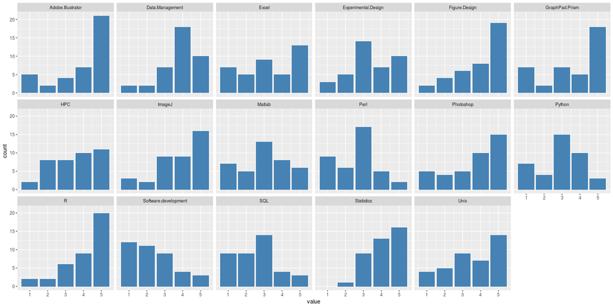

# Know your audience

Take RNA-seq;

- Do people want to run the analysis themselves?
- Or understand the basics and be able to interpret the output
- maybe do some downstream analysis?
- In our case it seems to be a mix of the two
- Influence on choice of software
- R, jupyter notebook?
- Galaxy?

# What we give them!

- R
- Introductory
- Intermediate (with dpylr and ggplot2)
- Statistics
- using “Shiny”
- Python
- Galaxy Introduction
- RNA-seq / ChIP-seq
- Experimental Design
- Data Management
- IGV
- Unix
- github
- Figure Design

# Availability of Materials

http://www.cruk.cam.ac.uk/core-facilities/bioinformatics-core/training

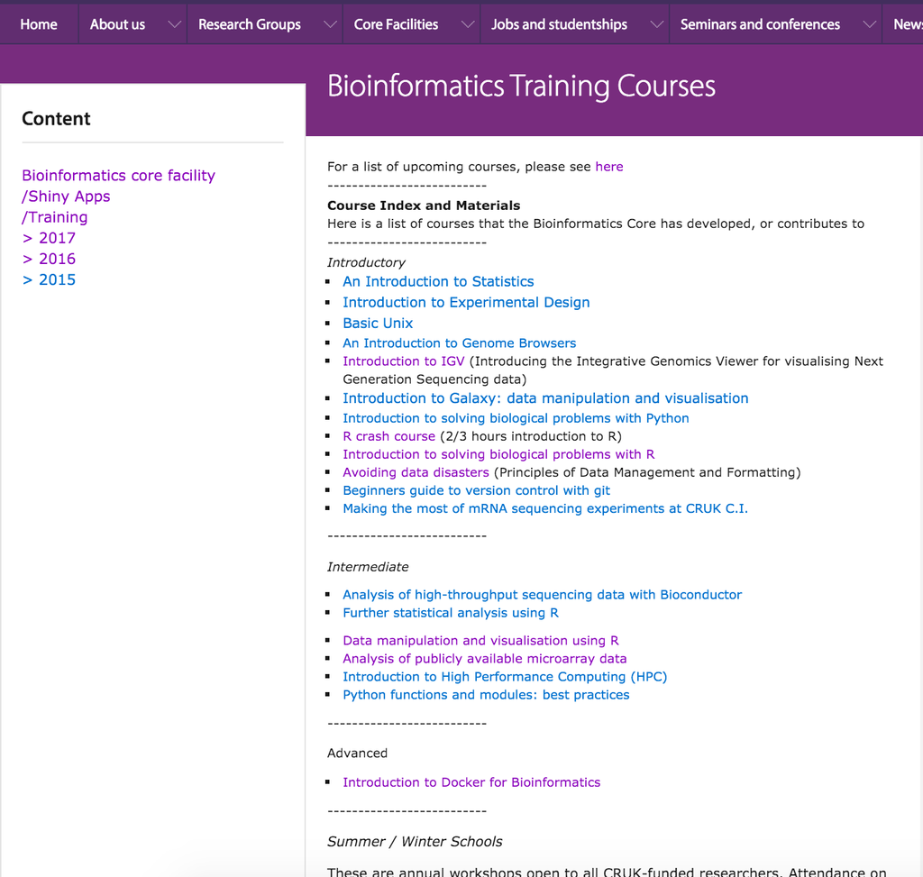

# Case Study: Intermediate R

- A one-day course to teach dplyr and ggplot2
- Three individuals involved in creating materials
- Mark Dunning, Matt Eldridge (CRUK CI), Thomas Carroll (MRC CSC, now Rockefeller Institute)
- Back of envelope estimate; around 100 hours preparation time
- Materials created and presented in RStudio markdown
- Mixture of walkthrough and exercises
- Materials available on github

# Benefits to the Core

- Visibility
- Create links with community
- Better interactions between Bioinformatician and Biologist
- Feedback after course is usually positive
- but we haven’t assessed long-term feedback yet
- Steering committee are happy
- Fun!

# It might not be as hard as you think

- Plenty of resources out there
- beg, steal, borrow!
- Technologies for easier creation of materials
- Rstudio, jupyter notebooks
- Technologies for easier software setup and deployment
- Virtual Machines, Docker, Cloud compute

# Let’s work together on this

[figure not shown]

# Extra

Number of CRUK C.I. employees attending a course + both internally and at University facilities

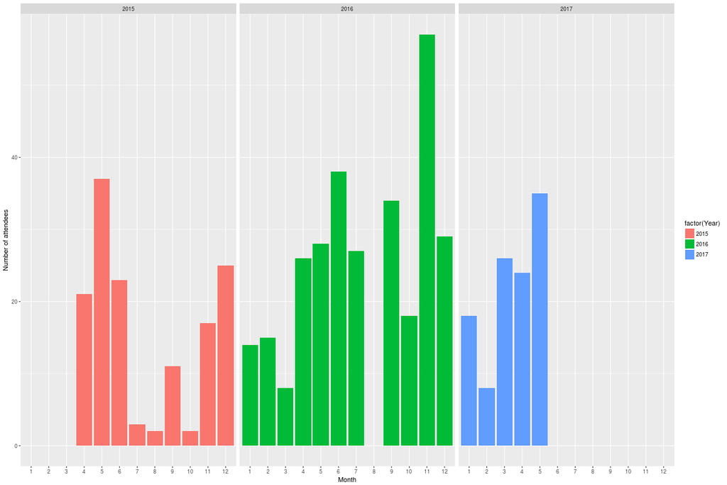

# Extra

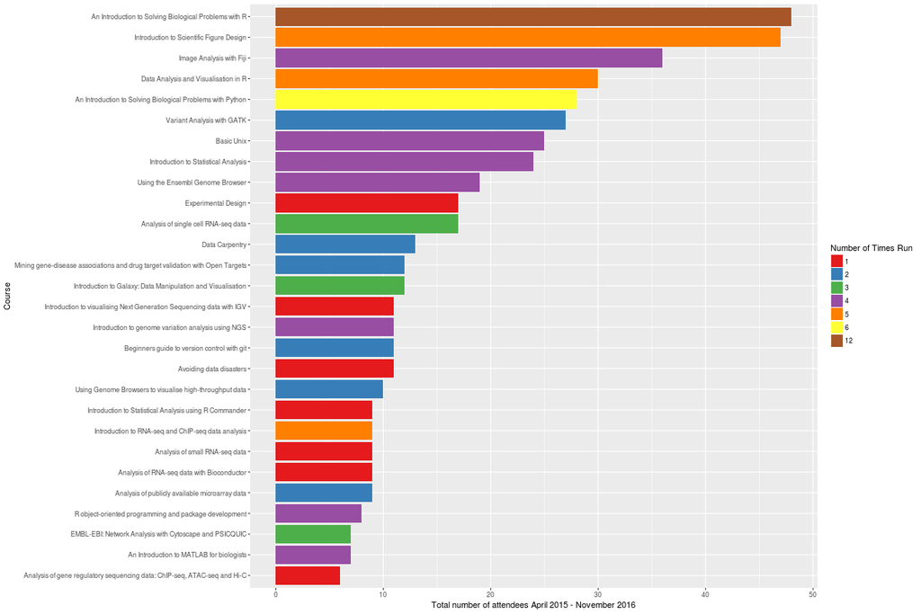